## Demand Forecasting Using Time Series Modeling: Case Study

### Background: In manufacturing sector, many decisions are taken based on forecasting future demand. The demand forecasting helps companies to manage accurate, timely and effective production. The sports goods manufacturing company identified 3 top products for which demand forecasting was most critical. The 5-years monthly sales data for 3 products was used to develop the model.

### Objective: Forecast next 3 months sales using trend and seasonality exhibited over 5 years of sales data.

#### Import data and display first 6 rows

```python
import os
import pandas as pd

os.chdir("D:/SANKHYA/Time Series Case Study/DATA")
salesdata = pd.read_csv('PRODUCT SALES DATA.csv')
salesdata.head(6)
```

```
   Year     Month  Product1  Product2  Product3
0  2014   January    123.57    118.69    120.51
1  2014  February    122.31    120.07    115.83
2  2014     March    123.20    119.84    115.44
3  2014     April    123.47    119.41    118.30
4  2014       May    127.16    119.57    128.64
5  2014      June    131.29    118.56    113.22
```

#### Data Description

| Column name | Column description |
| --- | --- |
| Year | Year of sales |
| Month | Month of sales |
| Product1,Product2,Product3 | Product sales (USD '000) |

#### Analysis of Product 1

#### Create a time series object and visualize sales over 5 years

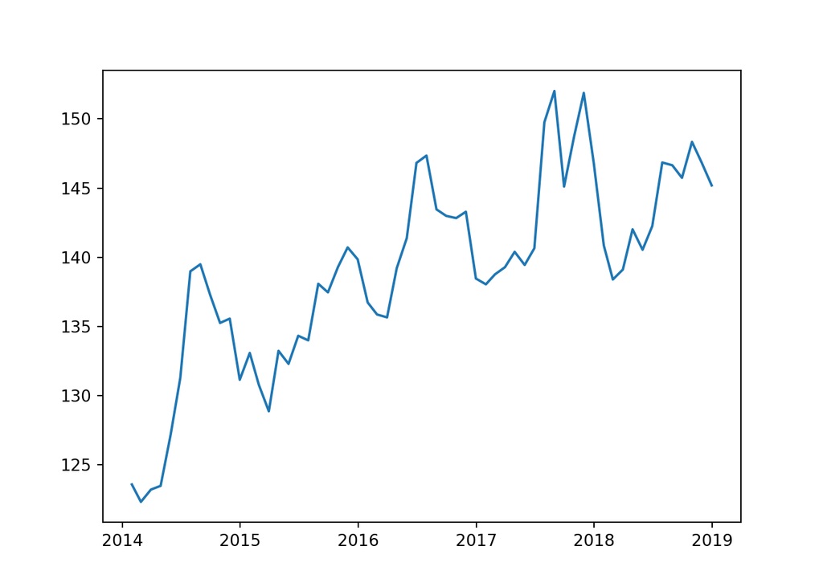

```python
import matplotlib.pyplot as plt

rng = pd.date_range('2014-01','2019-01',freq='M')

s1 = salesdata['Product1'].values[:60]
salesseries1 = pd.Series(s1, rng)

plt.plot(salesseries1);
plt.show()
```

#### The time series shows periodic peaks which indicates seasonality

#### Display ACF plot to check if product 1 sales forms stationary time series

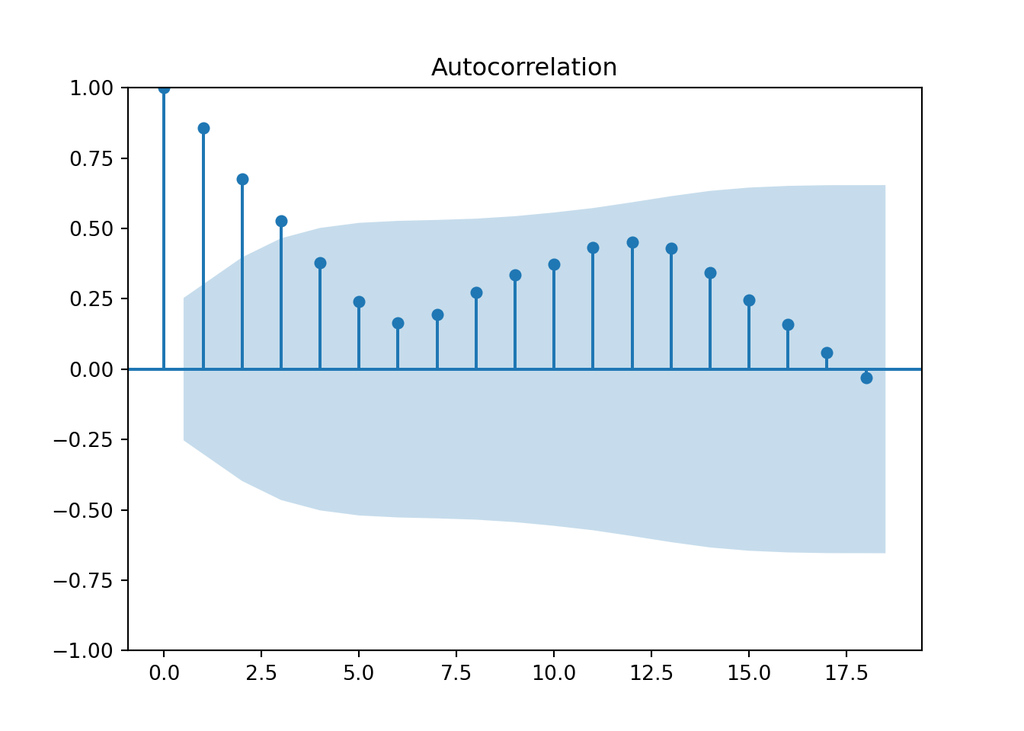

```python
from statsmodels.graphics.tsaplots import plot_acf
plot_acf(salesseries1);
plt.show()
```

#### ACF plot shows a slow decay indicating non-stationarity

#### Dickey-Fuller test for product 1 time series

```python
from arch.unitroot import ADF
import warnings

warnings.filterwarnings("ignore")

adf = ADF(salesseries1,lags=0,trend='nc')
adf.summary()
```

Augmented Dickey-Fuller Results

| Test Statistic | 0.798 |
| --- | --- |
| P-value | 0.885 |
| Lags | 0 |

Trend: No Trend  
Critical Values: -2.60 (1%), -1.95 (5%), -1.61 (10%)  
Null Hypothesis: The process contains a unit root.  
Alternative Hypothesis: The process is weakly stationary.

#### Value of test statistic is greater than 5% critical value. Hence, Time series is non-stationary.

#### Dickey-Fuller test for 1st order differenced time series

```python
from statsmodels.tsa.statespace.tools import diff
warnings.filterwarnings("ignore")

salesdiff1 = diff(salesseries1)
(ADF(salesdiff1,lags=0,trend='nc')).summary()
```

Augmented Dickey-Fuller Results

| Test Statistic | -6.541 |
| --- | --- |
| P-value | 0.000 |
| Lags | 0 |

Trend: No Trend  
Critical Values: -2.61 (1%), -1.95 (5%), -1.61 (10%)  
Null Hypothesis: The process contains a unit root.  
Alternative Hypothesis: The process is weakly stationary.

#### Value of test statistic is less than 5% critical value. Hence, Time series is stationary.

#### Automatic Model Identification and Parameter Estimation

#### Store auto.arima in object salesmodel1 and then get coefficients

```python
import pmdarima as pm
salesseries1 = pd.to_numeric(salesseries1.astype(float))

salesmodel1 = pm.auto_arima(salesseries1,
                      max_p=2, max_q=2,
                      max_P=2,max_Q=2,
                      d=1,m=12,
                      seasonal=True,
                      D=1, suppress_warnings=True,
                      trace=True)
```

```
Performing stepwise search to minimize aic
 ARIMA(2,1,2)(1,1,1)[12]             : AIC=inf, Time=0.89 sec
 ARIMA(0,1,0)(0,1,0)[12]             : AIC=259.386, Time=0.01 sec
 ARIMA(1,1,0)(1,1,0)[12]             : AIC=246.003, Time=0.04 sec
 ARIMA(0,1,1)(0,1,1)[12]             : AIC=inf, Time=0.15 sec
 ARIMA(1,1,0)(0,1,0)[12]             : AIC=261.049, Time=0.01 sec
 ARIMA(1,1,0)(2,1,0)[12]             : AIC=241.518, Time=0.12 sec
 ARIMA(1,1,0)(2,1,1)[12]             : AIC=inf, Time=0.64 sec
 ARIMA(1,1,0)(1,1,1)[12]             : AIC=inf, Time=0.23 sec
 ARIMA(0,1,0)(2,1,0)[12]             : AIC=239.838, Time=0.06 sec
 ARIMA(0,1,0)(1,1,0)[12]             : AIC=244.197, Time=0.02 sec
 ARIMA(0,1,0)(2,1,1)[12]             : AIC=inf, Time=0.55 sec
 ARIMA(0,1,0)(1,1,1)[12]             : AIC=inf, Time=0.24 sec
 ARIMA(0,1,1)(2,1,0)[12]             : AIC=241.008, Time=0.11 sec
 ARIMA(1,1,1)(2,1,0)[12]             : AIC=239.839, Time=0.23 sec
 ARIMA(0,1,0)(2,1,0)[12] intercept   : AIC=241.478, Time=0.13 sec

Best model:  ARIMA(0,1,0)(2,1,0)[12]
Total fit time: 3.443 seconds
```

```python
salesmodel1
```

```
ARIMA(order=(0, 1, 0), scoring_args={}, seasonal_order=(2, 1, 0, 12),
      suppress_warnings=True, with_intercept=False)
```

```python
salesmodel1.aic()
```

```
239.83815107195417
```

```python
salesmodel1.params()
```

```
array([-0.87442987, -0.46168266,  6.69844933])
```

#### Check if residuals are white noise using Box-Pierce Test

```python
resi1 = pd.Series(salesmodel1.resid(),rng)

from statsmodels.stats.diagnostic import acorr_ljungbox
acorr_ljungbox(resi1, lags=None, boxpierce=True)
```

```
     lb_stat  lb_pvalue   bp_stat  bp_pvalue
1   0.010441   0.918612  0.009936   0.920598
2   0.023746   0.988197  0.022382   0.988871
3   0.026134   0.998885  0.024578   0.998983
4   0.196851   0.995463  0.178774   0.996235
5   0.263825   0.998269  0.238186   0.998647
6   0.451414   0.998380  0.401570   0.998839
7   0.474407   0.999535  0.421225   0.999687
8   0.519147   0.999846  0.458750   0.999904
9   0.553948   0.999953  0.487376   0.999973
10  0.554825   0.999989  0.488083   0.999994
```

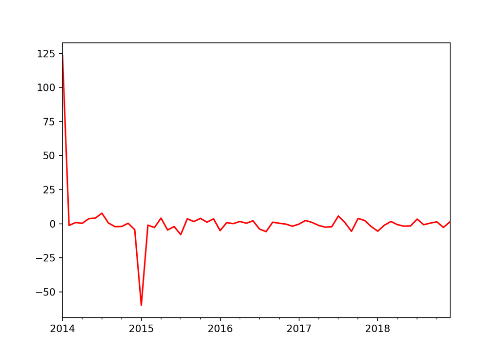

```python
resi1.plot(color='red')
plt.show()
```

#### Forecast product 1 sales for the next 3 months

```python
salesmodel1.predict(3)
```

```
array([142.8303097 , 142.41692126, 142.62500695])
```

#### Analysis of Product 2

#### Create a time series object and visualize sales over 5 years

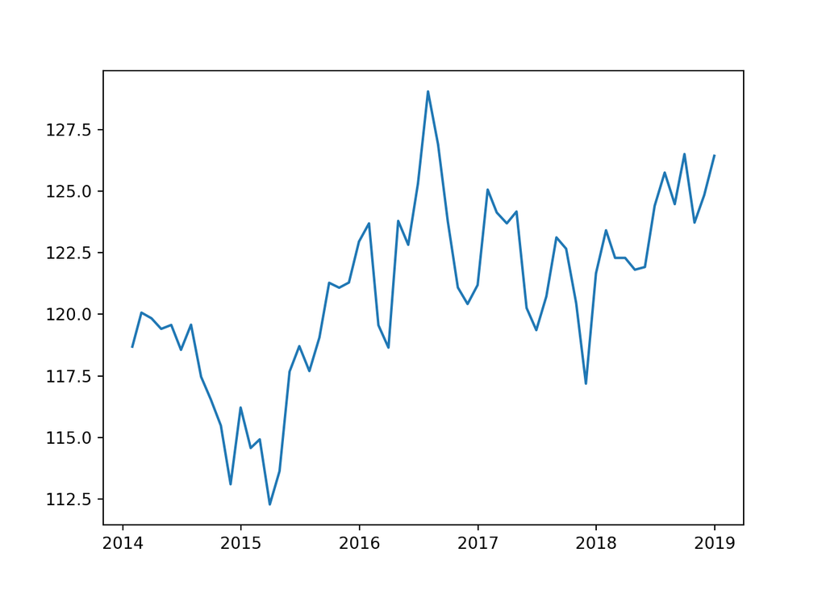

```python
import matplotlib.pyplot as plt

rng = pd.date_range('2014-01','2019-01',freq='M')

s2 = salesdata['Product2'].values[:60]
salesseries2 = pd.Series(s2, rng)

plt.plot(salesseries2);
plt.show()
```

#### The time series shows periodic peaks which indicates seasonality

#### Display ACF plot to check if product 2 sales forms stationary time series

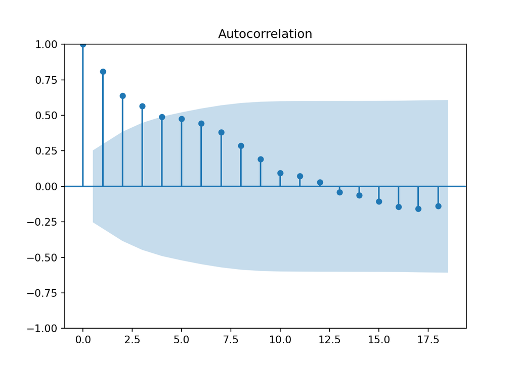

```python
from statsmodels.graphics.tsaplots import plot_acf
plot_acf(salesseries2);
plt.show()
```

#### ACF plot shows a slow decay indicating non-stationarity

#### Dickey-Fuller test for product 2 time series

```python
from arch.unitroot import ADF
import warnings

warnings.filterwarnings("ignore")

adf = ADF(salesseries2,lags=0,trend='nc')
adf.summary()
```

Augmented Dickey-Fuller Results

| Test Statistic | 0.417 |
| --- | --- |
| P-value | 0.805 |
| Lags | 0 |

Trend: No Trend  
Critical Values: -2.60 (1%), -1.95 (5%), -1.61 (10%)  
Null Hypothesis: The process contains a unit root.  
Alternative Hypothesis: The process is weakly stationary.

#### Value of test statistic is greater than 5% critical value. Hence, Time series is non-stationary.

#### Dickey-Fuller test for 1st order differenced time series

```python
from statsmodels.tsa.statespace.tools import diff
warnings.filterwarnings("ignore")

salesdiff2 = diff(salesseries2)
(ADF(salesdiff2,lags=0,trend='nc')).summary()
```

Augmented Dickey-Fuller Results

| Test Statistic | -7.667 |
| --- | --- |
| P-value | 0.000 |
| Lags | 0 |

Trend: No Trend  
Critical Values: -2.61 (1%), -1.95 (5%), -1.61 (10%)  
Null Hypothesis: The process contains a unit root.  
Alternative Hypothesis: The process is weakly stationary.

#### Value of test statistic is less than 5% critical value. Hence, Time series is stationary.

#### Automatic Model Identification and Parameter Estimation

#### Store auto.arima in object salesmodel2 and then get coefficients

```python
import pmdarima as pm
salesseries2 = pd.to_numeric(salesseries2.astype(float))

salesmodel2 = pm.auto_arima(salesseries2,
                            max_p=2, max_q=2,
                            max_P=2,max_Q=2,
                            d=1,m=12,
                            seasonal=True,
                            D=1, suppress_warnings=True,
                            trace=True)
```

```
Performing stepwise search to minimize aic
 ARIMA(2,1,2)(1,1,1)[12]             : AIC=inf, Time=0.42 sec
 ARIMA(0,1,0)(0,1,0)[12]             : AIC=236.357, Time=0.01 sec
 ARIMA(1,1,0)(1,1,0)[12]             : AIC=229.754, Time=0.04 sec
 ARIMA(0,1,1)(0,1,1)[12]             : AIC=inf, Time=0.18 sec
 ARIMA(1,1,0)(0,1,0)[12]             : AIC=238.353, Time=0.02 sec
 ARIMA(1,1,0)(2,1,0)[12]             : AIC=220.195, Time=0.11 sec
 ARIMA(1,1,0)(2,1,1)[12]             : AIC=inf, Time=0.62 sec
 ARIMA(1,1,0)(1,1,1)[12]             : AIC=inf, Time=0.24 sec
 ARIMA(0,1,0)(2,1,0)[12]             : AIC=218.365, Time=0.07 sec
 ARIMA(0,1,0)(1,1,0)[12]             : AIC=227.795, Time=0.03 sec
 ARIMA(0,1,0)(2,1,1)[12]             : AIC=inf, Time=0.51 sec
 ARIMA(0,1,0)(1,1,1)[12]             : AIC=inf, Time=0.13 sec
 ARIMA(0,1,1)(2,1,0)[12]             : AIC=220.110, Time=0.12 sec
 ARIMA(1,1,1)(2,1,0)[12]             : AIC=inf, Time=0.63 sec
 ARIMA(0,1,0)(2,1,0)[12] intercept   : AIC=220.364, Time=0.12 sec

Best model:  ARIMA(0,1,0)(2,1,0)[12]
Total fit time: 3.238 seconds
```

```python
salesmodel2
```

```
ARIMA(order=(0, 1, 0), scoring_args={}, seasonal_order=(2, 1, 0, 12),
      suppress_warnings=True, with_intercept=False)
```

```python
salesmodel2.aic()
```

```
218.36512988588333
```

```python
salesmodel2.params()
```

```
array([-0.75977563, -0.63807391,  3.8641199 ])
```

#### Check if residuals are white noise using Box-Pierce Test

```python
resi2 = pd.Series(salesmodel2.resid(),rng)

from statsmodels.stats.diagnostic import acorr_ljungbox
acorr_ljungbox(resi2, lags=None, boxpierce=True)
```

```
     lb_stat  lb_pvalue   bp_stat  bp_pvalue
1   0.000788   0.977605  0.000750   0.978154
2   0.016710   0.991680  0.015644   0.992208
3   0.016988   0.999414  0.015900   0.999469
4   0.020778   0.999946  0.019323   0.999954
5   0.021229   0.999997  0.019724   0.999997
6   0.032430   0.999999  0.029479   0.999999
7   0.051499   1.000000  0.045780   1.000000
8   0.068152   1.000000  0.059748   1.000000
9   0.071356   1.000000  0.062383   1.000000
10  0.106839   1.000000  0.090998   1.000000
```

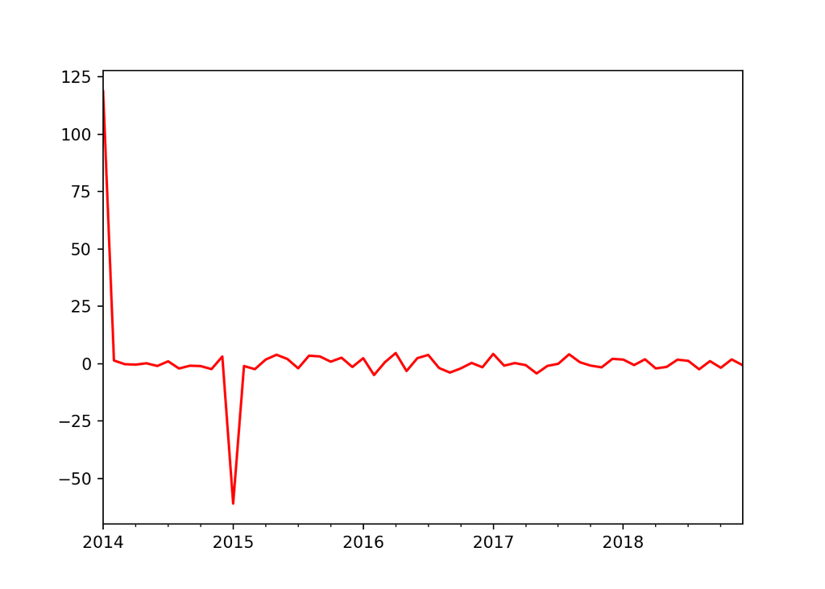

```python
resi2.plot(color='red')
plt.show()
```

#### Forecast product 2 sales for the next 3 months

```python
salesmodel2.predict(3)
```

```
array([127.79355301, 124.77607387, 124.14187786])
```

#### Analysis of Product 3

#### Create a time series object and visualize sales over 5 years

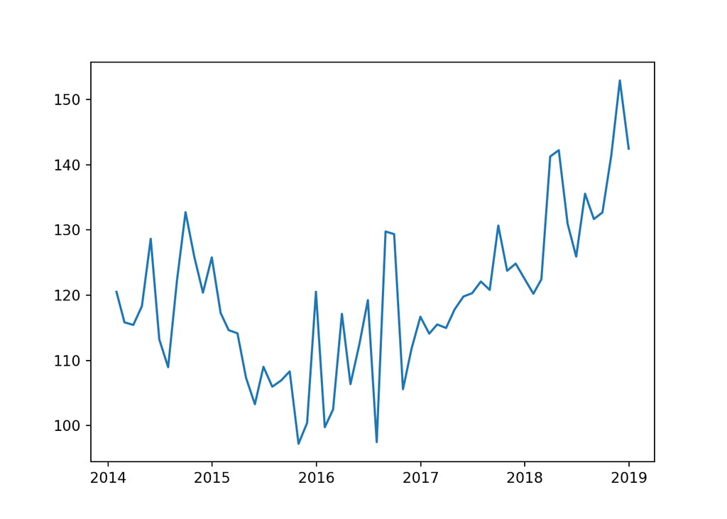

```python
import matplotlib.pyplot as plt

rng = pd.date_range('2014-01','2019-01',freq='M')

s3 = salesdata['Product3'].values[:60]
salesseries3 = pd.Series(s3, rng)

plt.plot(salesseries3);
plt.show()
```

#### The time series shows periodic peaks which indicates seasonality

#### Display ACF plot to check if product 3 sales forms stationary time series

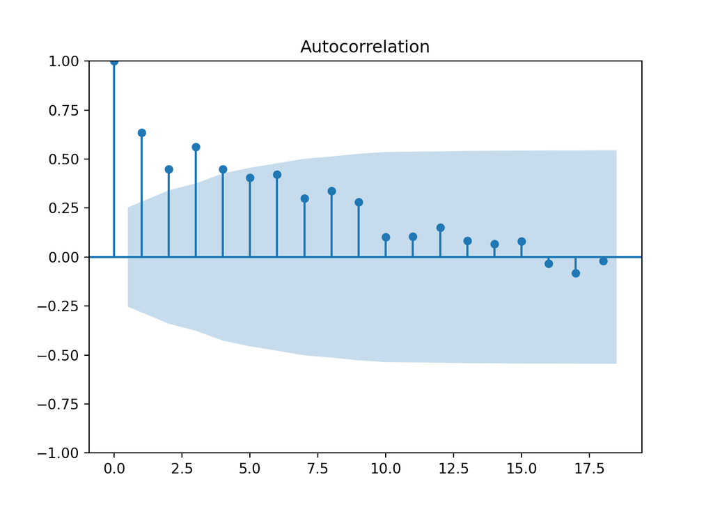

```python
from statsmodels.graphics.tsaplots import plot_acf
plot_acf(salesseries3);
plt.show()
```

#### ACF plot shows a slow decay indicating non-stationarity

#### Dickey-Fuller test for product 3 time series

```python
from arch.unitroot import ADF
import warnings

warnings.filterwarnings("ignore")

adf = ADF(salesseries3,lags=0,trend='nc')
adf.summary()
```

Augmented Dickey-Fuller Results

| Test Statistic | 0.008 |
| --- | --- |
| P-value | 0.687 |
| Lags | 0 |

Trend: No Trend  
Critical Values: -2.60 (1%), -1.95 (5%), -1.61 (10%)  
Null Hypothesis: The process contains a unit root.  
Alternative Hypothesis: The process is weakly stationary.

#### Value of test statistic is greater than 5% critical value. Hence, Time series is non-stationary.

#### Dickey-Fuller test for 1st order differenced time series

```python
from statsmodels.tsa.statespace.tools import diff
warnings.filterwarnings("ignore")

salesdiff3 = diff(salesseries3)
(ADF(salesdiff3,lags=0,trend='nc')).summary()
```

Augmented Dickey-Fuller Results

| Test Statistic | -10.396 |
| --- | --- |
| P-value | 0.000 |
| Lags | 0 |

Trend: No Trend  
Critical Values: -2.61 (1%), -1.95 (5%), -1.61 (10%)  
Null Hypothesis: The process contains a unit root.  
Alternative Hypothesis: The process is weakly stationary.

#### Value of test statistic is less than 5% critical value. Hence, Time series is stationary.

#### Automatic Model Identification and Parameter Estimation

#### Store auto.arima in object salesmodel3 and then get coefficients

```python
import pmdarima as pm
salesseries3 = pd.to_numeric(salesseries3.astype(float))

salesmodel3 = pm.auto_arima(salesseries3,
                            max_p=2, max_q=2,
                            max_P=2,max_Q=2,
                            d=1,m=12,
                            seasonal=True,
                            D=1, suppress_warnings=True,
                            trace=True)
```

```
Performing stepwise search to minimize aic
 ARIMA(2,1,2)(1,1,1)[12]             : AIC=inf, Time=0.44 sec
 ARIMA(0,1,0)(0,1,0)[12]             : AIC=374.830, Time=0.01 sec
 ARIMA(1,1,0)(1,1,0)[12]             : AIC=367.152, Time=0.06 sec
 ARIMA(0,1,1)(0,1,1)[12]             : AIC=356.136, Time=0.06 sec
 ARIMA(0,1,1)(0,1,0)[12]             : AIC=362.328, Time=0.02 sec
 ARIMA(0,1,1)(1,1,1)[12]             : AIC=358.032, Time=0.16 sec
 ARIMA(0,1,1)(0,1,2)[12]             : AIC=358.015, Time=0.25 sec
 ARIMA(0,1,1)(1,1,0)[12]             : AIC=358.388, Time=0.06 sec
 ARIMA(0,1,1)(1,1,2)[12]             : AIC=inf, Time=0.71 sec
 ARIMA(0,1,0)(0,1,1)[12]             : AIC=366.946, Time=0.03 sec
 ARIMA(1,1,1)(0,1,1)[12]             : AIC=357.841, Time=0.10 sec
 ARIMA(0,1,2)(0,1,1)[12]             : AIC=357.178, Time=0.14 sec
 ARIMA(1,1,0)(0,1,1)[12]             : AIC=364.335, Time=0.19 sec
 ARIMA(1,1,2)(0,1,1)[12]             : AIC=356.740, Time=0.29 sec
 ARIMA(0,1,1)(0,1,1)[12] intercept   : AIC=353.955, Time=0.22 sec
 ARIMA(0,1,1)(0,1,0)[12] intercept   : AIC=363.225, Time=0.09 sec
 ARIMA(0,1,1)(1,1,1)[12] intercept   : AIC=355.951, Time=0.34 sec
 ARIMA(0,1,1)(0,1,2)[12] intercept   : AIC=355.949, Time=0.43 sec
 ARIMA(0,1,1)(1,1,0)[12] intercept   : AIC=357.538, Time=0.10 sec
 ARIMA(0,1,1)(1,1,2)[12] intercept   : AIC=inf, Time=0.69 sec
 ARIMA(0,1,0)(0,1,1)[12] intercept   : AIC=368.653, Time=0.06 sec
 ARIMA(1,1,1)(0,1,1)[12] intercept   : AIC=inf, Time=0.40 sec
 ARIMA(0,1,2)(0,1,1)[12] intercept   : AIC=inf, Time=0.32 sec
 ARIMA(1,1,0)(0,1,1)[12] intercept   : AIC=365.692, Time=0.08 sec
 ARIMA(1,1,2)(0,1,1)[12] intercept   : AIC=inf, Time=0.41 sec

Best model:  ARIMA(0,1,1)(0,1,1)[12] intercept
Total fit time: 5.695 seconds
```

```python
salesmodel3
```

```
ARIMA(order=(0, 1, 1), scoring_args={}, seasonal_order=(0, 1, 1, 12),
      suppress_warnings=True)
```

```python
salesmodel3.aic()
```

```
353.954994784069
```

```python
salesmodel3.params()
```

```
array([ 0.58090072, -0.81695227, -0.83533598, 69.36021728])
```

#### Check if residuals are white noise using Box-Pierce Test

```python
resi3 = pd.Series(salesmodel3.resid(),rng)

from statsmodels.stats.diagnostic import acorr_ljungbox
acorr_ljungbox(resi3, lags=None, boxpierce=True)
```

```
     lb_stat  lb_pvalue   bp_stat  bp_pvalue
1   0.011916   0.913077  0.011339   0.915198
2   0.078976   0.961281  0.074073   0.963641
3   0.534480   0.911254  0.492843   0.920461
4   1.158809   0.884833  1.056753   0.901072
5   2.054914   0.841496  1.851685   0.869263
6   2.069908   0.913158  1.864744   0.931708
7   2.794996   0.903297  2.484578   0.928254
8   3.089025   0.928647  2.731182   0.950079
9   3.089243   0.960651  2.731361   0.974001
10  3.125344   0.978318  2.760476   0.986513
```

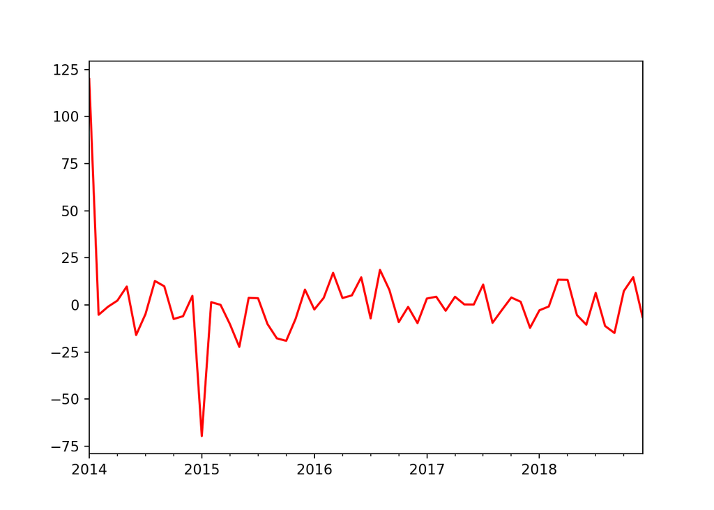

```python
resi3.plot(color='red')
plt.show()
```

#### Forecast product 3 sales for the next 3 months

```python
salesmodel3.predict(3)
```

```
array([141.12048721, 142.81789467, 151.49154238])
```

#### Table of forecasts

| Year | Month | Product1 | Product2 | Product3 |
| --- | --- | --- | --- | --- |
| 2019 | January | 142.8303 | 127.7936 | 141.1205 |
| 2019 | February | 142.4169 | 124.7761 | 142.8179 |
| 2019 | March | 142.6250 | 124.1419 | 151.4915 |